# ch05_07_VGG_CatvsDogs(4)

### 데이터 증식을 사용한 특성 추출

### 데이터 준비

```python
import os, shutil
```

```python
### 드라이브 마운트
from google.colab import drive
drive.mount('/content/drive')
```

```python
!cp -r '/content/drive/My Drive/dataset/cats_dogs'  '/content/'
!ls -ls '/content/cats_dogs'

# 압축풀기
!rm -rf '/content/datasets/'
!unzip '/content/cats_dogs/cats_and_dogs_test1.zip' -d '/content/datasets/'
!unzip '/content/cats_dogs/cats_and_dogs_train.zip' -d '/content/datasets/'

!ls -al '/content/datasets/train' | head -5
!ls -l '/content/datasets/train' | grep ^- | wc -l
!ls -al '/content/datasets/test1' | head -5
!ls -l '/content/datasets/test1' | grep ^- | wc -l
```

[output not shown]

[output cut: 4946 more lines]

```
  inflating: /content/datasets/train/dog.9997.jpg
  inflating: /content/datasets/train/dog.9998.jpg
  inflating: /content/datasets/train/dog.9999.jpg
total 609260
drwxr-xr-x 2 root root 770048 Sep 20  2013 .
drwxr-xr-x 4 root root   4096 Nov 15 00:13 ..
-rw-r--r-- 1 root root  12414 Sep 20  2013 cat.0.jpg
-rw-r--r-- 1 root root  21944 Sep 20  2013 cat.10000.jpg
25000
total 304268
drwxr-xr-x 2 root root 278528 Sep 20  2013 .
drwxr-xr-x 4 root root   4096 Nov 15 00:13 ..
-rw-r--r-- 1 root root  54902 Sep 20  2013 10000.jpg
-rw-r--r-- 1 root root  21671 Sep 20  2013 10001.jpg
12500
```

- 이 방법은 훨씬 느리고 비용이 많이 들지만 훈련하는 동안 데이터 증식 기법을 사용 가능
- conv_base 모델을 확장하고 입력 데이터를 사용해 엔드 투 엔드로 실행

```python
from keras.applications import VGG16

conv_base = VGG16(weights='imagenet',
                  include_top=False,
                  input_shape=(150, 150, 3))
```

```
Downloading data from https://storage.googleapis.com/tensorflow/keras-applications/vgg16/vgg16_weights_tf_dim_ordering_tf_kernels_notop.h5
```

```python
from keras import models
from keras import layers

model = models.Sequential()
model.add(conv_base)
model.add(layers.Flatten())
model.add(layers.Dense(256, activation='relu'))
model.add(layers.Dense(1, activation='sigmoid'))
```

### 모델의 구조

```python
model.summary()
```

```
Model: "sequential"
_________________________________________________________________
Layer (type)                 Output Shape              Param #
=================================================================
vgg16 (Functional)           (None, 4, 4, 512)         14714688
_________________________________________________________________
flatten (Flatten)            (None, 8192)              0
_________________________________________________________________
dense (Dense)                (None, 256)               2097408
_________________________________________________________________
dense_1 (Dense)              (None, 1)                 257
=================================================================
Total params: 16,812,353
Trainable params: 16,812,353
Non-trainable params: 0
_________________________________________________________________
```

- VGG16의 합성곱 기반층은 14,714,688개의 매우 많은 파라미터 보유
- 모델을 컴파일하고 훈련하기 전에 합성곱 기반층을 동결하는 것이 아주 중요
  - 하나 이상의 층을 동결한다는 것은 훈련하는 동안 가중치가 업데이트되지 않도록 막는다는 뜻
  - 이렇게 하지 않으면 합성곱 기반층에 의해 사전에 학습된 표현이 훈련하는 동안 수정
  - 맨 위의 Dense 층은 랜덤하게 초기화되었기 때문에 매우 큰 가중치 업데이트 값이 네트워크에 전파
  - 케라스에서는 trainable 속성을 False로 설정하여 네트워크를 동결

```python
print('conv_base를 동결하기 전 훈련되는 가중치의 수:',
      len(model.trainable_weights))
```

```
conv_base를 동결하기 전 훈련되는 가중치의 수: 30
```

```python
conv_base.trainable = False
```

```python
print('conv_base를 동결한 후 훈련되는 가중치의 수:',
      len(model.trainable_weights))
```

```
conv_base를 동결한 후 훈련되는 가중치의 수: 4
```

- 2개의 Dense층 가중치만 훈련
- 층마다 2개씩(가중치 행렬과 편향 벡터) 총 4개의 텐서가 훈련
- 컴파일 단계 후에 trainable 속성을 변경하면 반드시 모델을 다시 컴파일 해야 한다.

### 데이터 준비

```python
# 원본 데이터셋을 압축 해제한 디렉터리 경로
ori_dataset_dir = './datasets/train'

# 소규모 데이터셋을 저장할 디렉터리
base_dir = './datasets/cats_and_dogs_small'

# 반복실행을 위해 디렉터리 삭제
if os.path.exists(base_dir):
    shutil.rmtree(base_dir)
os.mkdir(base_dir)

# 훈련, 검증, 테스트 분할을 위한 디렉터리
train_dir = os.path.join(base_dir, 'train')
os.mkdir(train_dir)

val_dir = os.path.join(base_dir, 'validation')
os.mkdir(val_dir)

test_dir = os.path.join(base_dir, 'test')
os.mkdir(test_dir)

# 훈련용 고양이 사진 디렉터리
train_cats_dir = os.path.join(train_dir, 'cats')
os.mkdir(train_cats_dir)

# 훈련용 강아지 사진 디렉터리
train_dogs_dir = os.path.join(train_dir, 'dogs')
os.mkdir(train_dogs_dir)

# 검증용 고양이 사진 디렉터리
val_cats_dir = os.path.join(val_dir, 'cats')
os.mkdir(val_cats_dir)

# 검증용 강아지 사진 디렉터리
val_dogs_dir = os.path.join(val_dir, 'dogs')
os.mkdir(val_dogs_dir)

# 테스트용 고양이 사진 디렉터리
test_cats_dir = os.path.join(test_dir, 'cats')
os.mkdir(test_cats_dir)

# 테스트용 강아지 사진 디렉터리
test_dogs_dir = os.path.join(test_dir, 'dogs')
os.mkdir(test_dogs_dir)
```

```python
# 처음 1,000개의 고양이 이미지를 train_cats_dir에 복사합니다
fnames = ['cat.{}.jpg'.format(i) for i in range(1000)]
for fname in fnames:
    src = os.path.join(ori_dataset_dir, fname)
    dst = os.path.join(train_cats_dir, fname)
    shutil.copyfile(src, dst)

# 다음 500개 고양이 이미지를 validation_cats_dir에 복사합니다
fnames = ['cat.{}.jpg'.format(i) for i in range(1000, 1500)]
for fname in fnames:
    src = os.path.join(ori_dataset_dir, fname)
    dst = os.path.join(val_cats_dir, fname)
    shutil.copyfile(src, dst)

# 다음 500개 고양이 이미지를 test_cats_dir에 복사합니다
fnames = ['cat.{}.jpg'.format(i) for i in range(1500, 2000)]
for fname in fnames:
    src = os.path.join(ori_dataset_dir, fname)
    dst = os.path.join(test_cats_dir, fname)
    shutil.copyfile(src, dst)

# 처음 1,000개의 강아지 이미지를 train_dogs_dir에 복사합니다
fnames = ['dog.{}.jpg'.format(i) for i in range(1000)]
for fname in fnames:
    src = os.path.join(ori_dataset_dir, fname)
    dst = os.path.join(train_dogs_dir, fname)
    shutil.copyfile(src, dst)

# 다음 500개 강아지 이미지를 validation_dogs_dir에 복사합니다
fnames = ['dog.{}.jpg'.format(i) for i in range(1000, 1500)]
for fname in fnames:
    src = os.path.join(ori_dataset_dir, fname)
    dst = os.path.join(val_dogs_dir, fname)
    shutil.copyfile(src, dst)

# 다음 500개 강아지 이미지를 test_dogs_dir에 복사합니다
fnames = ['dog.{}.jpg'.format(i) for i in range(1500, 2000)]
for fname in fnames:
    src = os.path.join(ori_dataset_dir, fname)
    dst = os.path.join(test_dogs_dir, fname)
    shutil.copyfile(src, dst)

print('훈련용 고양이 이미지 전체 개수:', len(os.listdir(train_cats_dir)))
print('훈련용 강아지 이미지 전체 개수:', len(os.listdir(train_dogs_dir)))

print('검증용 고양이 이미지 전체 개수:', len(os.listdir(val_cats_dir)))
print('검증용 강아지 이미지 전체 개수:', len(os.listdir(val_dogs_dir)))

print('테스트용 고양이 이미지 전체 개수:', len(os.listdir(test_cats_dir)))
print('테스트용 강아지 이미지 전체 개수:', len(os.listdir(test_dogs_dir)))
```

```
훈련용 고양이 이미지 전체 개수: 1000
훈련용 강아지 이미지 전체 개수: 1000
검증용 고양이 이미지 전체 개수: 500
검증용 강아지 이미지 전체 개수: 500
테스트용 고양이 이미지 전체 개수: 500
테스트용 강아지 이미지 전체 개수: 500
```

```python
## 경로에 이미지 데이터의 개수
num_cats_tr = len(os.listdir(train_cats_dir))
num_dogs_tr = len(os.listdir(train_dogs_dir))

num_cats_val = len(os.listdir(val_cats_dir))
num_dogs_val = len(os.listdir(val_dogs_dir))

total_train = num_cats_tr + num_dogs_tr
total_val = num_cats_val + num_dogs_val

print("학습용 데이터 : ", total_train)
print("검증용 데이터 : ", total_val)

batch_size = 20
epochs = 30
```

```
학습용 데이터 :  2000
검증용 데이터 :  1000
```

```python
from keras.preprocessing.image import ImageDataGenerator
from keras import optimizers

train_datagen = ImageDataGenerator(
      rescale=1./255,
      rotation_range=20,
      width_shift_range=0.1,
      height_shift_range=0.1,
      shear_range=0.1,
      zoom_range=0.1,
      horizontal_flip=True,
      fill_mode='nearest')

# 검증 데이터는 증식되어서는 안 됩니다!
test_datagen = ImageDataGenerator(rescale=1./255)

train_generator = train_datagen.flow_from_directory(
        # 타깃 디렉터리
        train_dir,
        # 모든 이미지의 크기를 150 × 150로 변경합니다
        target_size=(150, 150),
        batch_size=20,
        # binary_crossentropy 손실을 사용하므로 이진 레이블이 필요합니다
        class_mode='binary')

validation_generator = test_datagen.flow_from_directory(
        val_dir,
        target_size=(150, 150),
        batch_size=20,
        class_mode='binary')

model.compile(loss='binary_crossentropy',
              optimizer=optimizers.RMSprop(lr=2e-5),
              metrics=['acc'])

history = model.fit_generator(
      train_generator,
      steps_per_epoch=100,  # total_train // batch_size
      epochs=30,
      validation_data=validation_generator,
      validation_steps=50,  # total_val // batch_size
      verbose=2)
```

```
Found 2000 images belonging to 2 classes.
Found 1000 images belonging to 2 classes.
WARNING:tensorflow:From <ipython-input-14-a09d61244b76>:42: Model.fit_generator (from tensorflow.python.keras.engine.training) is deprecated and will be removed in a future version.
Instructions for updating:
Please use Model.fit, which supports generators.
100/100 - 19s - loss: 0.5484 - acc: 0.7415 - val_loss: 0.4145 - val_acc: 0.8530
100/100 - 19s - loss: 0.4077 - acc: 0.8380 - val_loss: 0.3381 - val_acc: 0.8720
100/100 - 19s - loss: 0.3476 - acc: 0.8545 - val_loss: 0.3009 - val_acc: 0.8930
100/100 - 19s - loss: 0.3212 - acc: 0.8640 - val_loss: 0.2901 - val_acc: 0.8870
100/100 - 19s - loss: 0.2933 - acc: 0.8740 - val_loss: 0.2646 - val_acc: 0.8990
100/100 - 18s - loss: 0.2826 - acc: 0.8900 - val_loss: 0.2612 - val_acc: 0.8970
100/100 - 19s - loss: 0.2719 - acc: 0.8895 - val_loss: 0.2607 - val_acc: 0.8920
100/100 - 19s - loss: 0.2602 - acc: 0.8965 - val_loss: 0.2454 - val_acc: 0.8960
100/100 - 19s - loss: 0.2604 - acc: 0.8980 - val_loss: 0.2417 - val_acc: 0.9020
100/100 - 19s - loss: 0.2538 - acc: 0.8920 - val_loss: 0.2496 - val_acc: 0.9040
100/100 - 19s - loss: 0.2454 - acc: 0.8970 - val_loss: 0.2410 - val_acc: 0.9040
100/100 - 18s - loss: 0.2401 - acc: 0.9020 - val_loss: 0.2397 - val_acc: 0.9050
100/100 - 18s - loss: 0.2346 - acc: 0.9080 - val_loss: 0.2354 - val_acc: 0.9040
100/100 - 19s - loss: 0.2331 - acc: 0.9080 - val_loss: 0.2390 - val_acc: 0.8980
100/100 - 18s - loss: 0.2322 - acc: 0.9060 - val_loss: 0.2360 - val_acc: 0.8990
100/100 - 18s - loss: 0.2181 - acc: 0.9100 - val_loss: 0.2401 - val_acc: 0.9040
100/100 - 18s - loss: 0.2181 - acc: 0.9130 - val_loss: 0.2373 - val_acc: 0.9060
100/100 - 18s - loss: 0.2080 - acc: 0.9160 - val_loss: 0.2370 - val_acc: 0.9000
100/100 - 18s - loss: 0.2056 - acc: 0.9125 - val_loss: 0.2350 - val_acc: 0.9080
100/100 - 18s - loss: 0.2074 - acc: 0.9130 - val_loss: 0.2569 - val_acc: 0.8920
100/100 - 18s - loss: 0.2045 - acc: 0.9170 - val_loss: 0.2342 - val_acc: 0.8970
100/100 - 18s - loss: 0.2048 - acc: 0.9225 - val_loss: 0.2392 - val_acc: 0.8980
100/100 - 18s - loss: 0.1939 - acc: 0.9215 - val_loss: 0.2305 - val_acc: 0.9040
100/100 - 18s - loss: 0.1968 - acc: 0.9215 - val_loss: 0.2304 - val_acc: 0.9050
100/100 - 18s - loss: 0.1971 - acc: 0.9260 - val_loss: 0.2322 - val_acc: 0.9050
100/100 - 18s - loss: 0.1939 - acc: 0.9225 - val_loss: 0.2368 - val_acc: 0.9050
100/100 - 18s - loss: 0.1876 - acc: 0.9240 - val_loss: 0.2337 - val_acc: 0.9050
100/100 - 18s - loss: 0.1925 - acc: 0.9225 - val_loss: 0.2310 - val_acc: 0.9040
100/100 - 18s - loss: 0.1723 - acc: 0.9330 - val_loss: 0.2695 - val_acc: 0.8880
100/100 - 18s - loss: 0.1781 - acc: 0.9345 - val_loss: 0.2326 - val_acc: 0.9040
```

```python
model.save('cats_and_dogs_small_3_dataAug_VGG_30_epoch.h5')
```

```python
import matplotlib.pyplot as plt
```

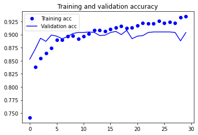

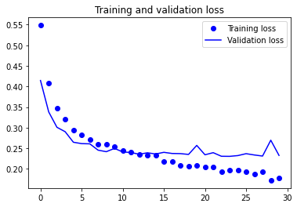

```python
acc = history.history['acc']
val_acc = history.history['val_acc']
loss = history.history['loss']
val_loss = history.history['val_loss']

epochs = range(len(acc))

plt.plot(epochs, acc, 'bo', label='Training acc')
plt.plot(epochs, val_acc, 'b', label='Validation acc')
plt.title('Training and validation accuracy')
plt.legend()

plt.figure()

plt.plot(epochs, loss, 'bo', label='Training loss')
plt.plot(epochs, val_loss, 'b', label='Validation loss')
plt.title('Training and validation loss')
plt.legend()

plt.show()
```

### 미세 조정

- 모델을 재사용하는 데 널리 사용되는 또 하나의 기법은 특성 추출을 보완하는 미세 조정
- 미세 조정은 특성 추출에 사용했던 동결 모델의 상위 층 몇 개를 동결에서 해제한다.
  - 모델에 새로 추가한 층(여기서는 완전 연결 분류기)과 함께 훈련하는 것.
  - 주어진 문제에 조금 더 밀접하게 재사용 모델의 표현을 일부 조정하기 때문에 미세 조정이라고 부른다.

[figure not shown]

- 같은 이유로 맨 위에 있는 분류기가 훈련된 후에 합성곱 기반의 상위 층을 미세 조정 가능.
- 분류기가 미리 훈련되지 않으면 훈련되는 동안 너무 큰 오차 신호가 네트워크에 전파됩니다.
  - 미세 조정될 층들이 사전에 학습한 표현들을 망가뜨리게 될 것입니다. 네트워크를 미세 조정하는 단계:
    - 01 사전에 훈련된 기반 네트워크 위에 새로운 네트워크를 추가합니다.
    - 02 기반 네트워크를 동결합니다.
    - 03 새로 추가한 네트워크를 훈련합니다.
    - 04 기반 네트워크에서 일부 층의 동결을 해제합니다.
    - 05 동결을 해제한 층과 새로 추가한 층을 함께 훈련합니다.
- 처음 세 단계는 특성 추출을 할 때 이미 완료했습니다.
- 네 번째 단계를 진행해 보죠. conv_base의 동결을 해제하고 개별 층을 동결하겠습니다.

```python
conv_base.summary()
```

```
Model: "vgg16"
_________________________________________________________________
Layer (type)                 Output Shape              Param #
=================================================================
input_1 (InputLayer)         [(None, 150, 150, 3)]     0
_________________________________________________________________
block1_conv1 (Conv2D)        (None, 150, 150, 64)      1792
_________________________________________________________________
block1_conv2 (Conv2D)        (None, 150, 150, 64)      36928
_________________________________________________________________
block1_pool (MaxPooling2D)   (None, 75, 75, 64)        0
_________________________________________________________________
block2_conv1 (Conv2D)        (None, 75, 75, 128)       73856
_________________________________________________________________
block2_conv2 (Conv2D)        (None, 75, 75, 128)       147584
_________________________________________________________________
block2_pool (MaxPooling2D)   (None, 37, 37, 128)       0
_________________________________________________________________
block3_conv1 (Conv2D)        (None, 37, 37, 256)       295168
_________________________________________________________________
block3_conv2 (Conv2D)        (None, 37, 37, 256)       590080
_________________________________________________________________
block3_conv3 (Conv2D)        (None, 37, 37, 256)       590080
_________________________________________________________________
block3_pool (MaxPooling2D)   (None, 18, 18, 256)       0
_________________________________________________________________
block4_conv1 (Conv2D)        (None, 18, 18, 512)       1180160
_________________________________________________________________
block4_conv2 (Conv2D)        (None, 18, 18, 512)       2359808
_________________________________________________________________
block4_conv3 (Conv2D)        (None, 18, 18, 512)       2359808
_________________________________________________________________
block4_pool (MaxPooling2D)   (None, 9, 9, 512)         0
_________________________________________________________________
block5_conv1 (Conv2D)        (None, 9, 9, 512)         2359808
_________________________________________________________________
block5_conv2 (Conv2D)        (None, 9, 9, 512)         2359808
_________________________________________________________________
block5_conv3 (Conv2D)        (None, 9, 9, 512)         2359808
_________________________________________________________________
block5_pool (MaxPooling2D)   (None, 4, 4, 512)         0
=================================================================
Total params: 14,714,688
Trainable params: 0
Non-trainable params: 14,714,688
_________________________________________________________________
```

- 마지막 세 개의 합성곱 층을 미세 조정하겠습니다. 즉, block4_pool까지 모든 층은 동결되고 block5_conv1, block5_conv2, block5_conv3 층은 학습 대상

```python
conv_base.trainable = True

set_trainable = False
for layer in conv_base.layers:
    if layer.name == 'block5_conv1':
        set_trainable = True
    if set_trainable:
        layer.trainable = True
    else:
        layer.trainable = False
```

```python
model.compile(loss='binary_crossentropy',
              optimizer=optimizers.RMSprop(lr=1e-5),
              metrics=['acc'])


history = model.fit_generator(
      train_generator,
      steps_per_epoch=100,  # total_train // batch_size
      epochs=50,
      validation_data=validation_generator,
      validation_steps=50,  # total_val // batch_size
      verbose=2)
```

```
100/100 - 19s - loss: 0.1926 - acc: 0.9225 - val_loss: 0.2385 - val_acc: 0.9050
100/100 - 19s - loss: 0.1503 - acc: 0.9375 - val_loss: 0.2272 - val_acc: 0.9150
100/100 - 19s - loss: 0.1404 - acc: 0.9480 - val_loss: 0.2354 - val_acc: 0.9100
100/100 - 19s - loss: 0.1191 - acc: 0.9510 - val_loss: 0.2683 - val_acc: 0.9020
100/100 - 19s - loss: 0.0970 - acc: 0.9635 - val_loss: 0.2339 - val_acc: 0.9200
100/100 - 19s - loss: 0.0986 - acc: 0.9635 - val_loss: 0.2167 - val_acc: 0.9180
100/100 - 19s - loss: 0.0815 - acc: 0.9735 - val_loss: 0.2269 - val_acc: 0.9210
100/100 - 19s - loss: 0.0827 - acc: 0.9700 - val_loss: 0.2424 - val_acc: 0.9160
100/100 - 19s - loss: 0.0663 - acc: 0.9740 - val_loss: 0.2036 - val_acc: 0.9280
100/100 - 19s - loss: 0.0575 - acc: 0.9805 - val_loss: 0.2406 - val_acc: 0.9180
100/100 - 19s - loss: 0.0585 - acc: 0.9795 - val_loss: 0.2250 - val_acc: 0.9260
100/100 - 19s - loss: 0.0528 - acc: 0.9795 - val_loss: 0.2170 - val_acc: 0.9310
100/100 - 19s - loss: 0.0380 - acc: 0.9890 - val_loss: 0.2324 - val_acc: 0.9300
100/100 - 19s - loss: 0.0429 - acc: 0.9820 - val_loss: 0.2428 - val_acc: 0.9250
100/100 - 19s - loss: 0.0336 - acc: 0.9880 - val_loss: 0.2684 - val_acc: 0.9180
100/100 - 19s - loss: 0.0331 - acc: 0.9870 - val_loss: 0.2322 - val_acc: 0.9290
100/100 - 19s - loss: 0.0267 - acc: 0.9925 - val_loss: 0.2610 - val_acc: 0.9200
100/100 - 19s - loss: 0.0273 - acc: 0.9895 - val_loss: 0.2535 - val_acc: 0.9230
100/100 - 19s - loss: 0.0204 - acc: 0.9940 - val_loss: 0.2390 - val_acc: 0.9270
100/100 - 19s - loss: 0.0232 - acc: 0.9920 - val_loss: 0.2652 - val_acc: 0.9210
100/100 - 19s - loss: 0.0235 - acc: 0.9915 - val_loss: 0.2847 - val_acc: 0.9220
100/100 - 19s - loss: 0.0216 - acc: 0.9925 - val_loss: 0.2540 - val_acc: 0.9290
100/100 - 19s - loss: 0.0180 - acc: 0.9950 - val_loss: 0.3345 - val_acc: 0.9140
100/100 - 19s - loss: 0.0136 - acc: 0.9950 - val_loss: 0.2664 - val_acc: 0.9250
100/100 - 19s - loss: 0.0136 - acc: 0.9960 - val_loss: 0.2568 - val_acc: 0.9330
100/100 - 19s - loss: 0.0132 - acc: 0.9955 - val_loss: 0.2546 - val_acc: 0.9330
100/100 - 19s - loss: 0.0142 - acc: 0.9940 - val_loss: 0.3254 - val_acc: 0.9200
100/100 - 19s - loss: 0.0191 - acc: 0.9955 - val_loss: 0.2480 - val_acc: 0.9270
100/100 - 19s - loss: 0.0149 - acc: 0.9970 - val_loss: 0.2583 - val_acc: 0.9280
100/100 - 19s - loss: 0.0119 - acc: 0.9970 - val_loss: 0.4922 - val_acc: 0.8940
100/100 - 19s - loss: 0.0154 - acc: 0.9945 - val_loss: 0.2622 - val_acc: 0.9350
100/100 - 19s - loss: 0.0085 - acc: 0.9970 - val_loss: 0.2886 - val_acc: 0.9250
100/100 - 18s - loss: 0.0112 - acc: 0.9975 - val_loss: 0.4349 - val_acc: 0.9100
100/100 - 19s - loss: 0.0105 - acc: 0.9975 - val_loss: 0.2614 - val_acc: 0.9310
100/100 - 18s - loss: 0.0089 - acc: 0.9970 - val_loss: 0.3011 - val_acc: 0.9300
100/100 - 19s - loss: 0.0158 - acc: 0.9940 - val_loss: 0.2635 - val_acc: 0.9350
100/100 - 19s - loss: 0.0104 - acc: 0.9960 - val_loss: 0.2620 - val_acc: 0.9320
100/100 - 18s - loss: 0.0073 - acc: 0.9975 - val_loss: 0.2808 - val_acc: 0.9310
100/100 - 18s - loss: 0.0094 - acc: 0.9975 - val_loss: 0.2876 - val_acc: 0.9270
100/100 - 18s - loss: 0.0060 - acc: 0.9985 - val_loss: 0.2924 - val_acc: 0.9360
100/100 - 19s - loss: 0.0051 - acc: 0.9980 - val_loss: 0.3231 - val_acc: 0.9330
100/100 - 18s - loss: 0.0113 - acc: 0.9955 - val_loss: 0.2831 - val_acc: 0.9340
100/100 - 18s - loss: 0.0038 - acc: 0.9985 - val_loss: 0.4054 - val_acc: 0.9150
100/100 - 18s - loss: 0.0032 - acc: 0.9990 - val_loss: 0.3033 - val_acc: 0.9330
100/100 - 19s - loss: 0.0044 - acc: 0.9990 - val_loss: 0.3200 - val_acc: 0.9340
100/100 - 18s - loss: 0.0036 - acc: 0.9990 - val_loss: 0.3244 - val_acc: 0.9300
100/100 - 18s - loss: 0.0047 - acc: 0.9985 - val_loss: 0.3222 - val_acc: 0.9330
100/100 - 18s - loss: 0.0083 - acc: 0.9975 - val_loss: 0.3041 - val_acc: 0.9340
100/100 - 18s - loss: 0.0052 - acc: 0.9990 - val_loss: 0.3027 - val_acc: 0.9350
100/100 - 18s - loss: 0.0037 - acc: 0.9990 - val_loss: 0.3689 - val_acc: 0.9270
```

```python
model.save('cats_and_dogs_small_4_misetunning_50.h5')
```

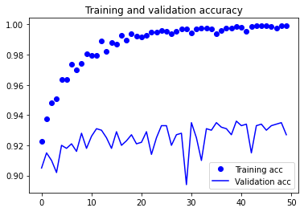

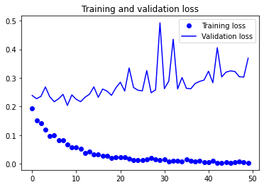

```python
acc = history.history['acc']
val_acc = history.history['val_acc']
loss = history.history['loss']
val_loss = history.history['val_loss']

epochs = range(len(acc))

plt.plot(epochs, acc, 'bo', label='Training acc')
plt.plot(epochs, val_acc, 'b', label='Validation acc')
plt.title('Training and validation accuracy')
plt.legend()

plt.figure()

plt.plot(epochs, loss, 'bo', label='Training loss')
plt.plot(epochs, val_loss, 'b', label='Validation loss')
plt.title('Training and validation loss')
plt.legend()

plt.show()
```

### 마지막으로 테스트 데이터를 이용한 모델 평가

```python
test_generator = test_datagen.flow_from_directory(
        test_dir,
        target_size=(150, 150),
        batch_size=20,
        class_mode='binary')

test_loss, test_acc = model.evaluate_generator(test_generator, steps=50)
print('test acc:', test_acc)
```

```
Found 1000 images belonging to 2 classes.
WARNING:tensorflow:From <ipython-input-24-19f8443b6c42>:7: Model.evaluate_generator (from tensorflow.python.keras.engine.training) is deprecated and will be removed in a future version.
Instructions for updating:
Please use Model.evaluate, which supports generators.
test acc: 0.9229999780654907
```